# Text classification

Yun-hui Chen

> 將“是否為Jane作品”當作資料集的label，訓練模型來判斷哪些段落是哪個作者寫的，為二元分類問題

```r
packages = c("dplyr","tidytext","tidyverse","ggplot2", "tidyr","gutenbergr","glmnet","broom","rsample","caTools","caret","rpart","rpart.plot","e1071","textstem")
existing = as.character(installed.packages()[,1])
for(pkg in packages[!(packages %in% existing)]) install.packages(pkg)

library(dplyr)
library(tidytext)
library(ggplot2)
library(tidyr)
library(gutenbergr)
library(caTools)
library(caret)
library(rpart)
library(rpart.plot)
library(tm)
library(e1071)
library(textstem)
```

```r
load("classification.RData")
```

# 資料下載

```r
books <- gutenberg_works(title %in% c("The War of the Worlds","Pride and Prejudice")) %>%
  gutenberg_download(meta_fields = "title") %>%
  mutate(document = row_number())

books
```

| gutenberg_id | text | title | document |
| --- | --- | --- | --- |
| 36 | The War of the Worlds | The War of the Worlds | 1 |
| 36 |  | The War of the Worlds | 2 |
| 36 | by H. G. Wells [1898] | The War of the Worlds | 3 |
| 36 |  | The War of the Worlds | 4 |
| 36 |  | The War of the Worlds | 5 |
| 36 | But who shall dwell in these worlds if they be | The War of the Worlds | 6 |
| 36 | inhabited? . . . Are we or they Lords of the | The War of the Worlds | 7 |
| 36 | World? . . . And how are all things made for man?-- | The War of the Worlds | 8 |
| 36 | KEPLER (quoted in The Anatomy of Melancholy) | The War of the Worlds | 9 |
| 36 |  | The War of the Worlds | 10 |

[output cut: 990 more lines]

```r
NA
```

```r
table(books$title)
```

```
  Pride and Prejudice The War of the Worlds
                13030                  6474
```

# 資料前處理

> 進行斷詞、去除stopwords，並篩選出現太少次的字

```r
tidy_books <- books %>%
  unnest_tokens(word, text) %>%
  group_by(word) %>%
  anti_join(stop_words) %>%
  filter(n() > 10) %>% #只取出出現大於10次的字
  ungroup()
tidy_books
```

| gutenberg_id | title | document | word |
| --- | --- | --- | --- |
| 36 | The War of the Worlds | 1 | war |
| 36 | The War of the Worlds | 8 | world |
| 36 | The War of the Worlds | 13 | book |
| 36 | The War of the Worlds | 15 | coming |
| 36 | The War of the Worlds | 15 | martians |
| 36 | The War of the Worlds | 19 | chapter |
| 36 | The War of the Worlds | 21 | war |
| 36 | The War of the Worlds | 24 | believed |
| 36 | The War of the Worlds | 25 | world |
| 36 | The War of the Worlds | 25 | watched |

[output cut: 990 more lines]

```r
length(unique(tidy_books$word))
```

```
[1] 1234
```

```r
tidy_books$lemma = lemmatize_words(tidy_books$word)

head(tidy_books)
```

| gutenberg_id | title | document | word | lemma |
| --- | --- | --- | --- | --- |
| 36 | The War of the Worlds | 1 | war | war |
| 36 | The War of the Worlds | 8 | world | world |
| 36 | The War of the Worlds | 13 | book | book |
| 36 | The War of the Worlds | 15 | coming | come |
| 36 | The War of the Worlds | 15 | martians | martian |
| 36 | The War of the Worlds | 19 | chapter | chapter |

```r
length(unique(tidy_books$word)) - length(unique(tidy_books$lemma))
```

```
[1] 226
```

減少了226個字

> 在text classification問題上，對文字做去除stopwords、詞型還原(lemmatization)是一種feature selection的方式

查看兩本書的常用字

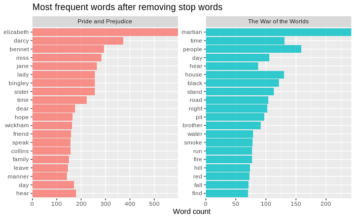

```r
tidy_books %>%
  count(title, lemma, sort = TRUE) %>%
  group_by(title) %>%
  top_n(20) %>%
  ungroup() %>%
  ggplot(aes(x=reorder(lemma,n),y=n,fill = title)) +
  geom_col(alpha = 0.8, show.legend = FALSE) +
  coord_flip() +
  facet_wrap(~title, scales = "free") +
  scale_y_continuous(expand = c(0, 0)) +
  labs(
    x = NULL, y = "Word count",
    title = "Most frequent words after removing stop words"
  )
```

兩本書的常用字很不一樣

## 轉成document term matrix

```r
dtm = tidy_books %>%
      count(document,lemma) %>%
      cast_dtm(document,lemma,n)

inspect(dtm[1:10,1:10])
```

```
<<DocumentTermMatrix (documents: 10, terms: 10)>>
Non-/sparse entries: 12/88
Sparsity           : 88%
Maximal term length: 8
Weighting          : term frequency (tf)
Sample             :
    Terms
Docs believe book chapter come creature man's martian war watch world
  1        0    0       0    0        0     0       0   1     0     0
  13       0    1       0    0        0     0       0   0     0     0
  15       0    0       0    1        0     0       1   0     0     0
  19       0    0       1    0        0     0       0   0     0     0
  21       0    0       0    0        0     0       0   1     0     0
  24       1    0       0    0        0     0       0   0     0     0
  25       0    0       0    0        0     0       0   0     1     1
  26       0    0       0    0        0     1       0   0     0     0
  29       0    0       0    0        1     0       0   0     0     0
  8        0    0       0    0        0     0       0   0     0     1
```

```r
dim(dtm) #14765個document 出現1008個不同的lemma
```

```
[1] 14765  1008
```

為dtm新增target欄位: is_jane 作者是否為jane (書是否為Pride and Prejudice)

```r
jane = unique(tidy_books$document[which(tidy_books$title == "Pride and Prejudice")])
```

```r
dtm = as.data.frame(as.matrix(dtm))
```

```r
dtm$is_jane = as.integer(rownames(dtm)) %in% jane
dtm$is_jane = as.factor(ifelse(dtm$is_jane,1,0)) #是jane為1,不是為0
```

```r
table(dtm$is_jane)
```

```
   0    1
4880 9885
```

# Model building

> 將資料分成訓練集與測試集

```r
set.seed(123)
spl = sample.split(dtm$is_jane, 0.7) #在保留is_jane比例的狀況下以7:3將原始資料分割成訓練集與測試集
TR = subset(dtm, spl == TRUE)
TS = subset(dtm, spl == FALSE)
```

查看是否保留is_jane比例

```r
sum(dtm$is_jane == 1)/nrow(dtm)
```

```
[1] 0.6694887
```

```r
sum(TR$is_jane == 1)/nrow(TR)
```

```
[1] 0.6695046
```

```r
sum(TS$is_jane == 1)/nrow(TS)
```

```
[1] 0.6694513
```

### Model building : logistic regression

```r
t0 = Sys.time()
## cost about 4 mins
glm = glm(is_jane~.,TR,family = "binomial") # 以is_jane作為y,其他欄位都當作x
```

```
glm.fit: fitted probabilities numerically 0 or 1 occurred
```

```r
Sys.time() - t0
```

```
Time difference of 2.79131 mins
```

```r
# 3.978 mins
```

```r
glm.pred = predict(glm,TS,type="response") #返回為is_jane為1的機率
```

confusion matrix

```r
cm = table(actual = TS$is_jane , pred = glm.pred >= 0.5);cm
```

```
      pred
actual FALSE TRUE
     0  1212  252
     1   234 2731
```

sensitivity : 在實際為1的資料中，預測多少為1

```r
sen  = 2731/(234+2731);sen # TP/(TP+FN) 0.9217538
```

```
[1] 0.9210793
```

specificity: 在實際為0的資料中，預測多少為0

```r
spec = 1212/(252+1212);spec # TN/(TN+FP)
```

```
[1] 0.8278689
```

> H.G WELLS的段落較容易被誤判

accuracy: 所有資料中有多少比例預測正確

```r
acc = sum(diag(cm))/sum(cm);acc # (TP+TN)/(TP+TN+FP+FN)
```

```
[1] 0.8902687
```

confusionMatrix(predict value,actual value)

```r
confusionMatrix(factor(ifelse(glm.pred >= 0.5,1,0)),factor(TS$is_jane),positive = "1")
```

```
Confusion Matrix and Statistics

          Reference
Prediction    0    1
         0 1212  234
         1  252 2731

               Accuracy : 0.8903
                 95% CI : (0.8807, 0.8993)
    No Information Rate : 0.6695
    P-Value [Acc > NIR] : <2e-16

                  Kappa : 0.7513

 Mcnemar's Test P-Value : 0.4406

            Sensitivity : 0.9211
            Specificity : 0.8279
         Pos Pred Value : 0.9155
         Neg Pred Value : 0.8382
             Prevalence : 0.6695
         Detection Rate : 0.6166
   Detection Prevalence : 0.6735
      Balanced Accuracy : 0.8745

       'Positive' Class : 1
```

ROC curve and AUC

```
             [,1]
0 vs. 1 0.9482342
```

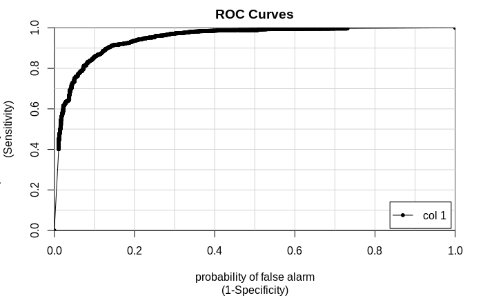

```r
colAUC(glm.pred,TS$is_jane,T)
```

### 各特徵的estimate係數

> 哪些特徵（詞）對於判斷分類影響很大？

```r
glm.summary = summary(glm)
```

```r
coef = as.data.frame(glm.summary$coefficients)
coef$term = row.names(coef)
```

> coefficient estimate代表特徵每增加一單位，y是1的發生機率比y是0的發生機率多幾倍（odds ratio 勝算比）

```r
head(coef)
```

|  | Estimate | Std. Error | z value | Pr(>\|z\|) | term |
| --- | --- | --- | --- | --- | --- |
| (Intercept) | 0.3396812 | 0.1042029 | 3.259805385 | 0.001114887 | (Intercept) |
| war | -35.5239617 | 6218.3814347 | -0.005712734 | 0.995441922 | war |
| world | 1.3027388 | 0.5272432 | 2.470849688 | 0.013479246 | world |
| book | -0.6549238 | 0.6438752 | -1.017159629 | 0.309077498 | book |
| come | -0.6634715 | 0.4891627 | -1.356341172 | 0.174990641 | come |
| martian | -35.0135695 | 3238.9104490 | -0.010810293 | 0.991374802 | martian |

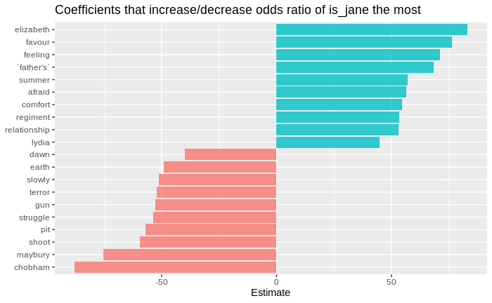

```r
coef %>%
  group_by(Estimate > 0) %>% # group_by兩類：Estimate > 0 或 Estimate <= 0
  top_n(10, abs(Estimate)) %>% #abs:絕對值
  ungroup() %>%
  ggplot(aes(reorder(term, Estimate), Estimate, fill = Estimate > 0)) +
  geom_col(alpha = 0.8, show.legend = FALSE) +
  coord_flip() +
  labs(
    x = NULL,
    title = "Coefficients that increase/decrease odds ratio of is_jane the most"
  )
```

> elizabeth,favor,feeling等字是影響判斷為Jane的重要字，chobham(hobham Armour 喬巴姆裝甲),maybury,shoot等字是影響判斷不是Jane的重要字

### 查看分類錯誤的句子

先確認在TS中的document id 順序與p.glm是一樣的

```r
identical(row.names(TS),names(glm.pred))
```

```
[1] TRUE
```

實際為傲慢與偏見，卻被判斷成世界大戰(False negative)

```r
books %>%
  filter(document %in% as.integer(row.names(TS))) %>%
  mutate(pred = glm.pred) %>% #因為確認了TS和pred中的document次序是相同的  所以可以直接mutate
  filter(pred < 0.5,title == "Pride and Prejudice") %>%
  top_n(-10,pred) #top_n(負數,col) 代表要根據col取最小的前
```

| gutenberg_id | text | title | document | pred |
| --- | --- | --- | --- | --- |
| 1342 | he might be always flying about from one place to another, and never | Pride and Prejudice | 6740 | 4.694989e-13 |
| 1342 | I liked a red coat myself very well--and, indeed, so I do still at my | Pride and Prejudice | 7438 | 2.220446e-16 |
| 1342 | "You are mistaken. I write rather slowly." | Pride and Prejudice | 8072 | 2.220446e-16 |
| 1342 | tickets, and a little bit of hot supper afterwards. The prospect of such | Pride and Prejudice | 9024 | 2.220446e-16 |
| 1342 | should have got into the coach. I was ready to die of laughter. And then | Pride and Prejudice | 13878 | 2.220446e-16 |
| 1342 | die of a broken heart; and then he will be sorry for what he has done." | Pride and Prejudice | 14065 | 2.220446e-16 |
| 1342 | with great perseverance. Yet time and her aunt moved slowly--and her | Pride and Prejudice | 14956 | 2.220446e-16 |
| 1342 | walking slowly towards the house. | Pride and Prejudice | 14962 | 2.220446e-16 |
| 1342 | faces, and displayed itself over their whole bodies, in a variety of | Pride and Prejudice | 15857 | 2.220446e-16 |
| 1342 | the first of September, than any body else in the country. | Pride and Prejudice | 16977 | 2.220446e-16 |

```r
NA
NA
```

實際為世界大戰，卻被判斷成傲慢與偏見(False positive)

```r
books %>%
  filter(document %in% as.integer(row.names(TS))) %>%
  mutate(pred = glm.pred) %>%
  filter(pred >= 0.5,title == "The War of the Worlds") %>%
  top_n(10,pred)
```

| gutenberg_id | text | title | document | pred |
| --- | --- | --- | --- | --- |
| 36 | Yet so vain is man, and so blinded by his vanity, that no writer, | The War of the Worlds | 55 | 1 |
| 36 | of his feelings invited me up to take a turn with him that night in a | The War of the Worlds | 137 | 1 |
| 36 | small and still, faintly marked with transverse stripes, and slightly | The War of the Worlds | 148 | 1 |
| 36 | deriving, I fancy, a certain comfort in one another's company. Then I | The War of the Worlds | 663 | 1 |
| 36 | "People seem fair silly about the common," said the woman over the | The War of the Worlds | 956 | 1 |
| 36 | I began to comfort her and myself by repeating all that Ogilvy had | The War of the Worlds | 995 | 1 |
| 36 | no reply--the man was killed--decided not to print a special edition. | The War of the Worlds | 1069 | 1 |
| 36 | regiment started from Aldershot. | The War of the Worlds | 1143 | 1 |
| 36 | entire battalion of the Cardigan Regiment. No details are known. | The War of the Worlds | 2573 | 1 |
| 36 | insufficient to reach me. I prayed copiously. It passed, scraping | The War of the Worlds | 4966 | 1 |

[output cut: 6 more lines]

```r
NA
NA
```

## TF-IDF

> 將每個段落視為一個document來計算字詞的TF-IDF

```r
document_words <- tidy_books %>% #計算每個document裡不同的字的tf
                  count(document, lemma, sort = TRUE)

total_words <- document_words %>%
                group_by(document) %>%
                summarize(total = sum(n)) %>%
                right_join(document_words) %>%
                mutate(is_jane = document %in% jane)
```

```r
total_words = total_words %>%
              bind_tf_idf(lemma,document,n)
```

將TF-ITF 轉為dtm的值

```r
dtm.tfidf = total_words %>% cast_dtm(document,lemma,tf_idf)
dim(dtm.tfidf)
```

```
[1] 14765  1008
```

```r
inspect(dtm.tfidf[1:10,1:10])
```

```
<<DocumentTermMatrix (documents: 10, terms: 10)>>
Non-/sparse entries: 10/90
Sparsity           : 90%
Maximal term length: 5
Weighting          : term frequency (tf)
Sample             :
       Terms
Docs    crowd day    death hour    kitty     mile near night     park     ulla
  19052     0   0 0.000000    0 5.395322 0.000000    0     0 0.000000 0.000000
  2018      0   0 2.931173    0 0.000000 0.000000    0     0 0.000000 0.000000
  5906      0   0 0.000000    0 0.000000 0.000000    0     0 0.000000 7.520573
  5914      0   0 0.000000    0 0.000000 0.000000    0     0 0.000000 6.016459
  5930      0   0 0.000000    0 0.000000 0.000000    0     0 0.000000 4.297470
  5966      0   0 0.000000    0 0.000000 0.000000    0     0 0.000000 6.016459
  5969      0   0 0.000000    0 0.000000 0.000000    0     0 3.531866 0.000000
  5977      0   0 0.000000    0 0.000000 0.000000    0     0 0.000000 4.297470
  6000      0   0 0.000000    0 0.000000 0.000000    0     0 0.000000 5.013716
  7659      0   0 0.000000    0 0.000000 4.281146    0     0 0.000000 0.000000
```

> 使用dtm.tfidf作為input來訓練model

```r
dtm.tfidf = as.data.frame(as.matrix(dtm.tfidf))
```

```r
dtm.tfidf$is_jane = as.integer(rownames(dtm.tfidf)) %in% jane
dtm.tfidf$is_jane = as.factor(ifelse(dtm.tfidf$is_jane,1,0))
```

```r
set.seed(123)
spl = sample.split(dtm.tfidf$is_jane, 0.7)
TR.tfidf = subset(dtm.tfidf, spl == TRUE)
TS.tfidf = subset(dtm.tfidf, spl == FALSE)
```

## logistic regression using dtm(weighting :tfidf)

```r
t0 = Sys.time()
glm.tfidf = glm(is_jane~.,TR.tfidf,family = "binomial")
```

```r
glm.tfidf.pred = predict(glm.tfidf,TS.tfidf,type="response") #返回為is_jane為1的機率
```

```
Error in eval(predvars, data, env) : object 'kitti' not found
```

```r
confusionMatrix(factor(ifelse(glm.tfidf.pred >= 0.5,1,0)),factor(TS.tfidf$is_jane),positive="1")
```

```
Confusion Matrix and Statistics

          Reference
Prediction    0    1
         0 1149  279
         1  315 2686

               Accuracy : 0.8659
                 95% CI : (0.8555, 0.8758)
    No Information Rate : 0.6695
    P-Value [Acc > NIR] : <2e-16

                  Kappa : 0.6951

 Mcnemar's Test P-Value : 0.151

            Sensitivity : 0.9059
            Specificity : 0.7848
         Pos Pred Value : 0.8950
         Neg Pred Value : 0.8046
             Prevalence : 0.6695
         Detection Rate : 0.6065
   Detection Prevalence : 0.6776
      Balanced Accuracy : 0.8454

       'Positive' Class : 1
```

## Model Building : SVM

### 以 dtm 為input

```r
svm.fit = svm(is_jane~.,TR,kernel = "linear",cost = 10,scale = F)
p.svm = pred = predict(svm.fit,TS)
```

```r
confusionMatrix(p.svm,TS$is_jane,dnn = c("Prediction","Reference"),positive = "1")
```

```
Confusion Matrix and Statistics

          Reference
Prediction    0    1
         0 1170  228
         1  294 2737

               Accuracy : 0.8821
                 95% CI : (0.8723, 0.8915)
    No Information Rate : 0.6695
    P-Value [Acc > NIR] : < 2.2e-16

                  Kappa : 0.7306

 Mcnemar's Test P-Value : 0.004442

            Sensitivity : 0.9231
            Specificity : 0.7992
         Pos Pred Value : 0.9030
         Neg Pred Value : 0.8369
             Prevalence : 0.6695
         Detection Rate : 0.6180
   Detection Prevalence : 0.6844
      Balanced Accuracy : 0.8611

       'Positive' Class : 1
```

### 以dtm.tfidf為input

```r
svm.fit.tfidf = svm(is_jane~.,TR.tfidf,kernel = "linear",cost = 10,scale = F)
p.svm.tfidf = pred = predict(svm.fit.tfidf,TS.tfidf)
```

```r
confusionMatrix(p.svm.tfidf,TS$is_jane,dnn = c("Prediction","Reference"),positive = "1")
```

```
Confusion Matrix and Statistics

          Reference
Prediction    0    1
         0 1155  237
         1  309 2728

               Accuracy : 0.8767
                 95% CI : (0.8667, 0.8863)
    No Information Rate : 0.6695
    P-Value [Acc > NIR] : < 2.2e-16

                  Kappa : 0.7179

 Mcnemar's Test P-Value : 0.002377

            Sensitivity : 0.9201
            Specificity : 0.7889
         Pos Pred Value : 0.8983
         Neg Pred Value : 0.8297
             Prevalence : 0.6695
         Detection Rate : 0.6159
   Detection Prevalence : 0.6857
      Balanced Accuracy : 0.8545

       'Positive' Class : 1
```

## Model Building : Decision tree

```r
t0 = Sys.time()
rp = rpart(is_jane~.,TR,method = "class")
Sys.time() - t0
```

```
Time difference of 33.43934 secs
```

```r
# 3.978 mins
```

決策樹視覺化

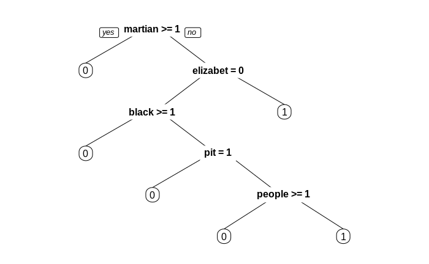

```r
prp(rp)
```

```r
p.rp = pred = predict(rp,TS)[,2] #predict(rp,TS) 會返回2種probability : 是0的機率,是1的機率 , 我們只取出 是1的機率
```

```r
confusionMatrix(factor(ifelse(pred >= 0.5,1,0)),factor(TS$is_jane),positive = "1")
```

```
Confusion Matrix and Statistics

          Reference
Prediction    0    1
         0  187   17
         1 1277 2948

               Accuracy : 0.7078
                 95% CI : (0.6942, 0.7212)
    No Information Rate : 0.6695
    P-Value [Acc > NIR] : 2.253e-08

                  Kappa : 0.156

 Mcnemar's Test P-Value : < 2.2e-16

            Sensitivity : 0.9943
            Specificity : 0.1277
         Pos Pred Value : 0.6978
         Neg Pred Value : 0.9167
             Prevalence : 0.6695
         Detection Rate : 0.6656
   Detection Prevalence : 0.9539
      Balanced Accuracy : 0.5610

       'Positive' Class : 1
```

> 在高維度資料上，特別是本次的document term，很難有一個特徵是可以決定區分兩個類別的，使決策樹的表現並不是很好。但決策樹的好處是易於解釋。

### 比較多個模型預測結果的ROC

```
              glm glm.tfidf       svm     rpart
0 vs. 1 0.9498013 0.8346106 0.8611416 0.5878916
```

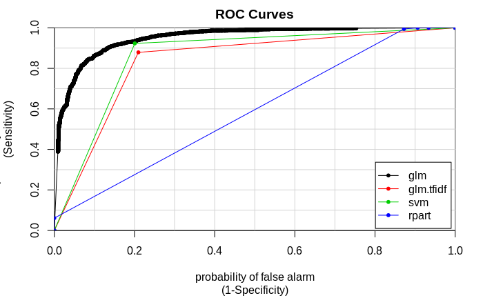

```r
colAUC(cbind(glm = p.glm,glm.tfidf = p.glm.tfidf , svm = p.svm , rpart = p.rp), TS$is_jane, T)
```

```r
save.image("classification.RData")
```